# netflix-eda-project-5

**IMPORTING THE LIBRARIES**

```python
import pandas as pd                 #perform a wide variety of mathematical operations on arrays
import numpy as np                  #analyzing, cleaning, exploring, and manipulating data.
import seaborn as sns               #provides statistical graphics for statistical data analysis
import matplotlib.pyplot as plt     #for creating static, animated, and interactive visualizations in Python.
import plotly.express as px         #library for simplified and concise data visualization in Python.
from textblob import TextBlob       #tasks like text classification, sentiment analysis, and part-of-speech tagging.
```

**LOADING THE DATASET**

```python
import pandas as pd

# Update the file path as needed
file_path = "netflix_titles.csv"

# Read the CSV file into a DataFrame
df = pd.read_csv(file_path)

# Sort the DataFrame by index
df.sort_index(inplace=True)

# Display the first few rows of the DataFrame
df.head()
```

|  | show_id | type | title | director | cast | country | date_added | release_year | rating | duration | listed_in | description |
| --- | --- | --- | --- | --- | --- | --- | --- | --- | --- | --- | --- | --- |
| 0 | s1 | Movie | Dick Johnson Is Dead | Kirsten Johnson | NaN | United States | September 25, 2021 | 2020 | PG-13 | 90 min | Documentaries | As her father nears the end of his life, filmm... |
| 1 | s2 | TV Show | Blood & Water | NaN | Ama Qamata, Khosi Ngema, Gail Mabalane, Thaban... | South Africa | September 24, 2021 | 2021 | TV-MA | 2 Seasons | International TV Shows, TV Dramas, TV Mysteries | After crossing paths at a party, a Cape Town t... |
| 2 | s3 | TV Show | Ganglands | Julien Leclercq | Sami Bouajila, Tracy Gotoas, Samuel Jouy, Nabi... | NaN | September 24, 2021 | 2021 | TV-MA | 1 Season | Crime TV Shows, International TV Shows, TV Act... | To protect his family from a powerful drug lor... |
| 3 | s4 | TV Show | Jailbirds New Orleans | NaN | NaN | NaN | September 24, 2021 | 2021 | TV-MA | 1 Season | Docuseries, Reality TV | Feuds, flirtations and toilet talk go down amo... |
| 4 | s5 | TV Show | Kota Factory | NaN | Mayur More, Jitendra Kumar, Ranjan Raj, Alam K... | India | September 24, 2021 | 2021 | TV-MA | 2 Seasons | International TV Shows, Romantic TV Shows, TV ... | In a city of coaching centers known to train I... |

```python
df.columns   #to return the column labels of the given Dataframe
```

```
Index(['show_id', 'type', 'title', 'director', 'cast', 'country', 'date_added',
       'release_year', 'rating', 'duration', 'listed_in', 'description'],
      dtype='object')
```

```python
df.shape   #used to get the dimensions of any Python
```

```
(8807, 12)
```

```python
df.isna().sum()   #function returns the number of NaN values in all columns of a Pandas DataFrame.
```

```
show_id            0
type               0
title              0
director        2634
cast             825
country          831
date_added        10
release_year       0
rating             4
duration           3
listed_in          0
description        0
dtype: int64
```

```python
df.fillna("Not Mentioned", inplace = True)
```

```python
df.isna().sum()
```

```
show_id         0
type            0
title           0
director        0
cast            0
country         0
date_added      0
release_year    0
rating          0
duration        0
listed_in       0
description     0
dtype: int64
```

```python
df.info()
```

```
<class 'pandas.core.frame.DataFrame'>
RangeIndex: 8807 entries, 0 to 8806
Data columns (total 12 columns):
 #   Column        Non-Null Count  Dtype
---  ------        --------------  -----
 0   show_id       8807 non-null   object
 1   type          8807 non-null   object
 2   title         8807 non-null   object
 3   director      8807 non-null   object
 4   cast          8807 non-null   object
 5   country       8807 non-null   object
 6   date_added    8807 non-null   object
 7   release_year  8807 non-null   int64
 8   rating        8807 non-null   object
 9   duration      8807 non-null   object
 10  listed_in     8807 non-null   object
 11  description   8807 non-null   object
dtypes: int64(1), object(11)
memory usage: 825.8+ KB
```

```python
df.dropna(inplace = True, axis = 0)    #dropping the rows which are not
```

```python
rat = df['rating'].value_counts().reset_index()
rat
```

|  | rating | count |
| --- | --- | --- |
| 0 | TV-MA | 3207 |
| 1 | TV-14 | 2160 |
| 2 | TV-PG | 863 |
| 3 | R | 799 |
| 4 | PG-13 | 490 |
| 5 | TV-Y7 | 334 |
| 6 | TV-Y | 307 |
| 7 | PG | 287 |
| 8 | TV-G | 220 |
| 9 | NR | 80 |
| 10 | G | 41 |
| 11 | TV-Y7-FV | 6 |
| 12 | Not Mentioned | 4 |
| 13 | NC-17 | 3 |
| 14 | UR | 3 |
| 15 | 74 min | 1 |
| 16 | 84 min | 1 |
| 17 | 66 min | 1 |

```python
# Create a pie chart with Plotly Express
fig = px.pie(rat, names = 'rating', values = 'count', title = 'Rating of shows and movies in Netflix', hole = 0.4)

# Change the figure size (width and height)
fig.update_layout(
    title_text="Rating of shows and movies in Netflix",  # Change the title text
    title_font=dict(size=25),  # Set the title font size (you can adjust the size as needed
    width=800,  # Set the width in pixels
    height=600)  # Set the height in pixels
fig.show()
```

[interactive chart not shown]

**The data depicted in the figure highlights a significant trend in Netflix's film offerings, with over 36.4% of the films receiving a "TV-MA" rating. This rating indicates that a substantial portion of Netflix's content is intended for mature audiences, featuring themes and content that may not be suitable for younger viewers. This suggests that Netflix caters to a diverse audience, including those seeking more mature and content-rich experiences. The streaming platform's commitment to providing a wide range of content options aligns with its efforts to meet the preferences and tastes of its diverse subscriber base.**

```python
tp = df['type'].value_counts().reset_index()
```

```python
mn = px.pie(tp, names = 'type', values = 'count')
# Change the figure size (width and height)
mn.update_layout(
    title_text="No of TV shows vs Movies in Netflix",  # Change the title text
    title_font=dict(size=25),  # Set the title font size (you can adjust the size as needed
    width=600,  # Set the width in pixels
    height=500)  # Set the height in pixels
mn.show()
```

[interactive chart not shown]

**The percentage of movies significantly exceeds that of TV shows on Netflix, emphasizing the platform's extensive library of films. This observation underscores Netflix's emphasis on providing a broad and diverse range of cinematic content, catering to various tastes and preferences among its subscribers. With a wealth of movie choices, Netflix offers an extensive and varied streaming experience for its viewers.**

```python
df.describe(include = 'object')
```

|  | show_id | type | title | director | cast | country | date_added | rating | duration | listed_in | description |
| --- | --- | --- | --- | --- | --- | --- | --- | --- | --- | --- | --- |
| count | 8807 | 8807 | 8807 | 8807 | 8807 | 8807 | 8807 | 8807 | 8807 | 8807 | 8807 |
| unique | 8807 | 2 | 8807 | 4529 | 7693 | 749 | 1768 | 18 | 221 | 514 | 8775 |
| top | s1 | Movie | Dick Johnson Is Dead | Not Mentioned | Not Mentioned | United States | January 1, 2020 | TV-MA | 1 Season | Dramas, International Movies | Paranormal activity at a lush, abandoned prope... |
| freq | 1 | 6131 | 1 | 2634 | 825 | 2818 | 109 | 3207 | 1793 | 362 | 4 |

```python
df = df[df['director'] != "Not Mentioned"]
```

```python
dr = df['director'].value_counts().reset_index()[:5]
dr
```

|  | director | count |
| --- | --- | --- |
| 0 | Rajiv Chilaka | 19 |
| 1 | Raúl Campos, Jan Suter | 18 |
| 2 | Marcus Raboy | 16 |
| 3 | Suhas Kadav | 16 |
| 4 | Jay Karas | 14 |

```python
# Create a bar chart with customizations using Plotly Express
cu = px.bar(dr, x='director', y='count',
             title='Top 5 directors', text='count',
             height=500, width=800)
cu.show()
```

[interactive chart not shown]

The plot visualizes the top 5 directors from a Netflix dataset

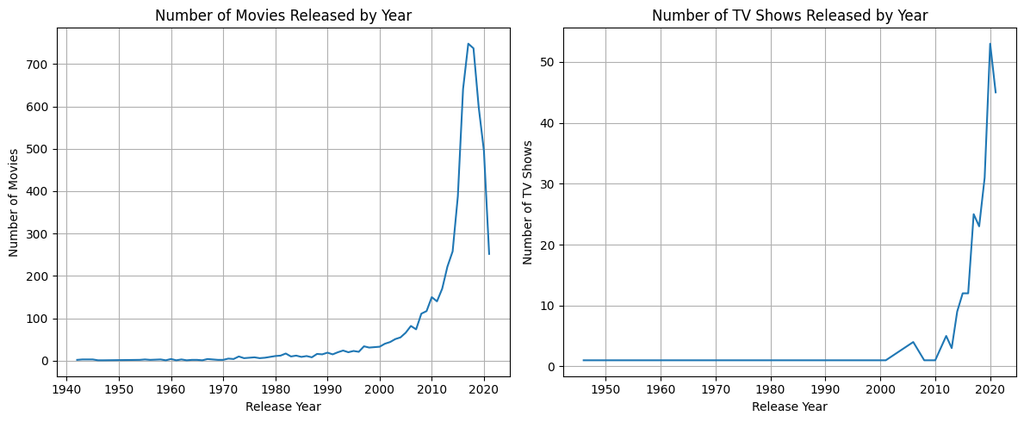

```python
# Separate data for movies and TV shows
movies_df = df[df['type'] == 'Movie']
tv_shows_df = df[df['type'] == 'TV Show']

# Count the number of movies and TV shows in each year
movie_counts = movies_df['release_year'].value_counts().sort_index()
tv_show_counts = tv_shows_df['release_year'].value_counts().sort_index()

# Create a figure with two subplots (side by side)
plt.figure(figsize=(12, 5))  # Adjust the figure size

# Create the first subplot for movies
plt.subplot(1, 2, 1)
plt.plot(movie_counts.index, movie_counts.values , linestyle='-')
plt.xlabel('Release Year')
plt.ylabel('Number of Movies')
plt.title('Number of Movies Released by Year')
plt.grid(True)

# Create the second subplot for TV shows
plt.subplot(1, 2, 2)
plt.plot(tv_show_counts.index, tv_show_counts.values, linestyle='-')
plt.xlabel('Release Year')
plt.ylabel('Number of TV Shows')
plt.title('Number of TV Shows Released by Year')
plt.grid(True)

# Adjust layout and display both subplots
plt.tight_layout()
plt.show()
```

**The figure provides an overview of the number of movies and TV shows released on Netflix across different years. Notably, there is a gradual increase in content production, with a significant uptick observed after the 2000s. This suggests a growing commitment to expanding the streaming library and catering to a wider audience. The data illustrates how Netflix has become a major player in content creation and distribution in the digital era, offering a diverse range of both movies and TV shows to its viewers.**

**SENTIMENT ANALYSIS**

In the context of sentiment analysis, `sentiment.polarity` is a property provided by the TextBlob library in Python. It represents a numeric value that quantifies the sentiment or emotional tone of a piece of text, such as a sentence or document. The `sentiment.polarity` property typically ranges from -1 to 1, where:

- Negative values (close to -1) indicate a negative sentiment, implying that the text expresses a predominantly negative or unfavorable sentiment.
- Positive values (close to 1) indicate a positive sentiment, suggesting that the text conveys a predominantly positive or favorable sentiment.
- A value of 0 indicates a neutral sentiment, meaning that the text is relatively emotionless or lacks a clear positive or negative tone.

The `sentiment.polarity` property is computed using various natural language processing (NLP) techniques, including analyzing the words and phrases in the text and assigning a numeric score based on the overall emotional tone expressed. This score is a simple way to assess the sentiment of text data for various applications, such as sentiment analysis, opinion mining, and more.

```python
df3 = df.loc[:,('release_year', 'description')]

sentiment = []
for index,row in df3.iterrows():
    d = row['description']
    testimonial = TextBlob(d)
    p = testimonial.sentiment.polarity
    if p == 0:
        sent = "Neutral"
    elif p > 0:
        sent = "Positive"
    else:
        sent = "Negative"
    sentiment.append(sent)

df3['Sentiments'] = sentiment
df3 = df3.groupby(['release_year', 'Sentiments']).size().reset_index(name = "Total Count")
df3 = df3[df3['release_year']>2005]

fig2 = px.bar(df3, x = 'release_year', y = 'Total Count', color = 'Sentiments',title="Sentiment Analysis of Content on Netflix")
fig2.show()
```

[interactive chart not shown]

It shows that the content on Netflix has increased over the years, and it has been analyzed for sentiment, categorizing it into positive, negative, and neutral sentiments. This suggests that Netflix's content library has been growing with a diverse range of sentiments expressed in the descriptions of the content. It's important to note that the sentiment analysis can provide insights into the emotional tone of the content

**SUMMARY**

Report: Netflix Content Analysis

This report presents an analysis of the content available on Netflix, covering various aspects such as content type, ratings, top directors, historical trends, and sentiment analysis. The analysis is based on the information provided.

**1. Content Type:**

- The data reveals that movies outnumber TV shows in the Netflix content library, indicating a larger collection of films available for streaming.

**3. Top Directors:**

**4. Content Growth:**

- A significant increase in content availability is observed, especially after the 2000s. This indicates Netflix's continual efforts to expand its content library to cater to a broader audience.

**5. Sentiment Analysis:**

- Sentiment analysis of content descriptions on Netflix reveals that there has been an increase in positive, neutral, and negative sentiments over the years. Notably, positive sentiment has shown a significant increase, possibly reflecting changes in content tone or audience preferences.

Overall, this analysis offers valuable insights into the composition and trends of Netflix's content. It's important to note that content availability can vary by region and evolve over time, and these findings are based on the provided data. Monitoring and analyzing content trends can help Netflix adapt its offerings to meet the changing preferences of its audience.